# CENTRO UNIVERSITÁRIO 7 DE SETEMBRO

# Especialização em Ciência de Dados com Big Data, BI e Data Analytics

# Disciplina: Análise Estatística de Dados

# Professor: Prof. Dr. Marcio Mota

## Equipe:

# Questão 1 (3 pontos):

Uma empresa seguradora deseja prever com maior segurança as possibilidades de indenização das apólices de seguro de automóveis quando assume um novo contrato. Assim, através do levantamento de registros anteriores, obteve os seguintes dados:

| Observação | Grupo | Tempo de Habilitação | Solteiro (1) Casado (2) Filhos? (3) | Número de Multas |
| --- | --- | --- | --- | --- |
| 1 | 1 | 20 | 3 | 1 |
| 2 | 1 | 21 | 3 | 0 |
| 3 | 1 | 25 | 3 | 2 |
| 4 | 1 | 25 | 2 | 3 |
| 5 | 1 | 18 | 2 | 2 |
| 6 | 1 | 23 | 1 | 2 |
| ------------ | ------- | ---------------------- | ------------------------------------- | ------------------ |
| 7 | 2 | 9 | 3 | 6 |
| 8 | 2 | 12 | 2 | 4 |
| 9 | 2 | 15 | 1 | 3 |
| 10 | 2 | 14 | 2 | 2 |
| 11 | 2 | 15 | 1 | 5 |
| 12 | 2 | 10 | 3 | 5 |
| 13 | 2 | 8 | 2 | 4 |
| ------------ | ------- | ---------------------- | ------------------------------------- | ------------------ |
| 14 | 3 | 7 | 2 | 13 |
| 15 | 3 | 11 | 1 | 15 |
| 16 | 3 | 10 | 2 | 9 |
| 17 | 3 | 7 | 2 | 6 |
| 18 | 3 | 9 | 1 | 10 |
| 19 | 3 | 1 | 3 | 8 |
| 20 | 3 | 3 | 1 | 5 |

Esses casos foram divididos em três grupos: (1) Baixo Risco, (2) Médio Risco e (3) Alto Risco. As variáveis consideradas representativas foram “tempo de habilitação”, “número de multas” sofridas desde que obteve sua habilitação e estado civil/existência ou não de filhos, assumindo os valores de 1 para solteiro, 2 para casado e 3 com filhos.

Pede-se: 1) Usando o método da distância de Mahalanobis, estabeleça o grau de risco de cada novo potencial cliente cujos dados são:

| Observação | Grupo | Tempo de Habilitação | Solteiro (1) Casado (2) Filhos? (3) | Número de Multas |
| --- | --- | --- | --- | --- |
| 1 | ? | 8 | 1 | 3 |
| 2 | ? | 2 | 1 | 6 |
| 3 | ? | 8 | 2 | 2 |
| 4 | ? | 20 | 2 | 4 |
| 5 | ? | 7 | 3 | 8 |
| 6 | ? | 15 | 3 | 1 |
| 7 | ? | 6 | 2 | 10 |
| 8 | ? | 3 | 3 | 5 |

2) Indique a probabilidade em que cada um dos novos clientes pode pertencer ao Grupo Correspondente e cria uma Regra de Negócio diante dessa problemática. Aponte ainda qual dessas três variáveis é a que mais discrimina a classificação dos Grupos.

# Solução

Vamos usar Análise Discriminante Múltipla para resolvermos esse problema de classificação de grupos, pois são mais de dois grupos para serem classificados. A análise discriminante trabalha com variáveis categóricas como variável dependente ou explicada (Grupo de Risco) e variáveis métricas para variáveis independentes ou explicativas (Tempo de Habilitação Solteiro, Estado Civil e Filhos e Número de Multas).

A regra a ser criada será baseada nas distâncias das observações aos centróides de cada grupo. A distância Mahalanobis será usada para esse fim: $$D_{mahala} = \sqrt(\frac{\sum(X_i - \overline{X}^2}{\sigma^2})$$

## PARTE 1

### Carregar os Dados das Observações

```python
import pandas as pd
import numpy as np
import scipy as sp
import statsmodels.formula.api as smf
import statsmodels.api as sm
import matplotlib.pyplot as plt
import seaborn as sns
import itertools

# Formatar o output de das variáveis no mesmo padrão
num_format_flo = "{:>22.10f}".format
num_format_int = "{:>3}".format
num_format_por = "{:>3.2f}".format

# Recriar a tabela conforme questão
df = pd.read_csv("https://www.dropbox.com/s/ciz8svyndvuddq2/Dados%20Q1.csv?dl=1", sep=";")
df = df.rename(columns = {"Tempo Hab": "Tempo_Hab",
                         "Solteiro/Casado/Filhos": "Solteiro_Casado_Filhos"})

df
```

|  | Observacao | Grupo | Tempo_Hab | Solteiro_Casado_Filhos | Multas |
| --- | --- | --- | --- | --- | --- |
| 0 | 1 | 1 | 20 | 3 | 1 |
| 1 | 2 | 1 | 21 | 3 | 0 |
| 2 | 3 | 1 | 25 | 3 | 2 |
| 3 | 4 | 1 | 25 | 2 | 3 |
| 4 | 5 | 1 | 18 | 2 | 2 |
| 5 | 6 | 1 | 23 | 1 | 2 |
| 6 | 7 | 2 | 9 | 3 | 6 |
| 7 | 8 | 2 | 12 | 2 | 4 |
| 8 | 9 | 2 | 15 | 1 | 3 |
| 9 | 10 | 2 | 14 | 2 | 2 |
| 10 | 11 | 2 | 15 | 1 | 5 |
| 11 | 12 | 2 | 10 | 3 | 5 |
| 12 | 13 | 2 | 8 | 2 | 4 |
| 13 | 14 | 3 | 7 | 2 | 13 |
| 14 | 15 | 3 | 11 | 1 | 15 |
| 15 | 16 | 3 | 10 | 2 | 9 |
| 16 | 17 | 3 | 7 | 2 | 6 |
| 17 | 18 | 3 | 9 | 1 | 10 |
| 18 | 19 | 3 | 1 | 3 | 8 |
| 19 | 20 | 3 | 3 | 1 | 5 |

### Separar as Variáveis:

- **Independente**: Tempo_Hab Solteiro_Casado_Filhos Multas
- Dependente: Grupo

```python
Xstr = list(df.columns.values[2:5])
Ystr =  df.columns.values[1]
Xstr, Ystr
```

```
(['Tempo_Hab', 'Solteiro_Casado_Filhos', 'Multas'], 'Grupo')
```

### Calcular da Média e Variância para cada grupo:

```python
df_stats = pd.DataFrame()
g = df.groupby('Grupo')['Grupo'].unique().values
grupos = []
for i, v in np.ndenumerate(g):
    grupos.append(v[0])

for i in grupos:
    df_stats['mean'+str(i)] = df.loc[df[Ystr] == i][Xstr].mean()
    df_stats['var'+str(i)] = df.loc[df[Ystr] == i][Xstr].var()

df_stats
```

|  | mean1 | var1 | mean2 | var2 | mean3 | var3 |
| --- | --- | --- | --- | --- | --- | --- |
| Tempo_Hab | 22.000000 | 8.000000 | 11.857143 | 8.476190 | 6.857143 | 13.476190 |
| Solteiro_Casado_Filhos | 2.333333 | 0.666667 | 2.000000 | 0.666667 | 1.714286 | 0.571429 |
| Multas | 1.666667 | 1.066667 | 4.142857 | 1.809524 | 9.428571 | 12.952381 |

### Calcular a Distância de Mahalanobis:

$$D_{mahala} = \sqrt(\frac{\sum(X_i - \overline{X}^2}{\sigma^2})$$

```python
for i in grupos:
    for j in grupos:
        if not 'mahala'+str(j) in df.columns:
            df['mahala'+str(j)] = 0
        soma = 0
        for v in Xstr:
            soma += (df[df[Ystr] == i][v] - df_stats['mean'+str(j)][v])**2 / (df_stats['var'+str(j)][v])
        mahala = np.sqrt(soma)
        df.loc[df[Ystr] == i, ['mahala'+str(j)]] = mahala.values

df
```

|  | Observacao | Grupo | Tempo_Hab | Solteiro_Casado_Filhos | Multas | mahala1 | mahala2 | mahala3 |
| --- | --- | --- | --- | --- | --- | --- | --- | --- |
| 0 | 1 | 1 | 20 | 3 | 1 | 1.258306 | 3.844643 | 4.603846 |
| 1 | 2 | 1 | 21 | 3 | 0 | 1.842779 | 4.565843 | 4.959718 |
| 2 | 3 | 1 | 25 | 3 | 2 | 1.376893 | 4.941296 | 5.619511 |
| 3 | 4 | 1 | 25 | 2 | 3 | 1.719981 | 4.593541 | 5.268686 |
| 4 | 5 | 1 | 18 | 2 | 2 | 1.506928 | 2.643755 | 3.690107 |
| 5 | 6 | 1 | 23 | 1 | 2 | 1.701715 | 4.322739 | 4.948794 |
| 6 | 7 | 2 | 9 | 3 | 6 | 6.276610 | 2.090238 | 2.034983 |
| 7 | 8 | 2 | 12 | 2 | 4 | 4.215547 | 0.116987 | 2.093015 |
| 8 | 9 | 2 | 15 | 1 | 3 | 3.233935 | 1.840417 | 3.000625 |
| 9 | 10 | 2 | 14 | 2 | 2 | 2.875906 | 1.754801 | 2.861700 |
| 10 | 11 | 2 | 15 | 1 | 5 | 4.382731 | 1.752525 | 2.706895 |
| 11 | 12 | 2 | 10 | 3 | 5 | 5.392897 | 1.520828 | 2.267157 |
| 12 | 13 | 2 | 8 | 2 | 4 | 5.456266 | 1.329096 | 1.585871 |
| 13 | 14 | 3 | 7 | 2 | 13 | 12.194603 | 6.792399 | 1.062610 |
| 14 | 15 | 3 | 11 | 1 | 15 | 13.581544 | 8.168815 | 2.136116 |
| 15 | 16 | 3 | 10 | 2 | 9 | 8.281505 | 3.666674 | 0.943399 |
| 16 | 17 | 3 | 7 | 2 | 6 | 6.774646 | 2.165484 | 1.025639 |
| 17 | 18 | 3 | 9 | 1 | 10 | 9.428459 | 4.628361 | 1.121964 |
| 18 | 19 | 3 | 1 | 3 | 8 | 9.664152 | 4.860937 | 2.365609 |
| 19 | 20 | 3 | 3 | 1 | 5 | 7.629439 | 3.340843 | 1.873773 |

### Calcular o Grupo de Risco Predito:

- Grupo predito de cada observação será o de menor distância ao Mahalanobis ao centróide de cada grupo.

```python
df['Grupo-Predito'] = -1
for i in range(len(df.index)):
    min_mahala = df.loc[i, 'mahala1':'mahala3'].min()
    min_mahala_serie = df.loc[i, 'mahala1':'mahala3'] == min_mahala
    for idx, row in min_mahala_serie.iteritems():
        if row:
            df.loc[i, 'Grupo-Predito'] = int(idx.replace('mahala',''))

df
```

|  | Observacao | Grupo | Tempo_Hab | Solteiro_Casado_Filhos | Multas | mahala1 | mahala2 | mahala3 | Grupo-Predito |
| --- | --- | --- | --- | --- | --- | --- | --- | --- | --- |
| 0 | 1 | 1 | 20 | 3 | 1 | 1.258306 | 3.844643 | 4.603846 | 1 |
| 1 | 2 | 1 | 21 | 3 | 0 | 1.842779 | 4.565843 | 4.959718 | 1 |
| 2 | 3 | 1 | 25 | 3 | 2 | 1.376893 | 4.941296 | 5.619511 | 1 |
| 3 | 4 | 1 | 25 | 2 | 3 | 1.719981 | 4.593541 | 5.268686 | 1 |
| 4 | 5 | 1 | 18 | 2 | 2 | 1.506928 | 2.643755 | 3.690107 | 1 |
| 5 | 6 | 1 | 23 | 1 | 2 | 1.701715 | 4.322739 | 4.948794 | 1 |
| 6 | 7 | 2 | 9 | 3 | 6 | 6.276610 | 2.090238 | 2.034983 | 3 |
| 7 | 8 | 2 | 12 | 2 | 4 | 4.215547 | 0.116987 | 2.093015 | 2 |
| 8 | 9 | 2 | 15 | 1 | 3 | 3.233935 | 1.840417 | 3.000625 | 2 |
| 9 | 10 | 2 | 14 | 2 | 2 | 2.875906 | 1.754801 | 2.861700 | 2 |
| 10 | 11 | 2 | 15 | 1 | 5 | 4.382731 | 1.752525 | 2.706895 | 2 |
| 11 | 12 | 2 | 10 | 3 | 5 | 5.392897 | 1.520828 | 2.267157 | 2 |
| 12 | 13 | 2 | 8 | 2 | 4 | 5.456266 | 1.329096 | 1.585871 | 2 |
| 13 | 14 | 3 | 7 | 2 | 13 | 12.194603 | 6.792399 | 1.062610 | 3 |
| 14 | 15 | 3 | 11 | 1 | 15 | 13.581544 | 8.168815 | 2.136116 | 3 |
| 15 | 16 | 3 | 10 | 2 | 9 | 8.281505 | 3.666674 | 0.943399 | 3 |
| 16 | 17 | 3 | 7 | 2 | 6 | 6.774646 | 2.165484 | 1.025639 | 3 |
| 17 | 18 | 3 | 9 | 1 | 10 | 9.428459 | 4.628361 | 1.121964 | 3 |
| 18 | 19 | 3 | 1 | 3 | 8 | 9.664152 | 4.860937 | 2.365609 | 3 |
| 19 | 20 | 3 | 3 | 1 | 5 | 7.629439 | 3.340843 | 1.873773 | 3 |

### Calcular o Acerto:

- Agora é preciso verificar se o grupo predito é igual ao grupo observado.

```python
df['Acertou'] = False
df['Acertou'] = (df[Ystr] == df['Grupo-Predito'])

df
```

|  | Observacao | Grupo | Tempo_Hab | Solteiro_Casado_Filhos | Multas | mahala1 | mahala2 | mahala3 | Grupo-Predito | Acertou |
| --- | --- | --- | --- | --- | --- | --- | --- | --- | --- | --- |
| 0 | 1 | 1 | 20 | 3 | 1 | 1.258306 | 3.844643 | 4.603846 | 1 | True |
| 1 | 2 | 1 | 21 | 3 | 0 | 1.842779 | 4.565843 | 4.959718 | 1 | True |
| 2 | 3 | 1 | 25 | 3 | 2 | 1.376893 | 4.941296 | 5.619511 | 1 | True |
| 3 | 4 | 1 | 25 | 2 | 3 | 1.719981 | 4.593541 | 5.268686 | 1 | True |
| 4 | 5 | 1 | 18 | 2 | 2 | 1.506928 | 2.643755 | 3.690107 | 1 | True |
| 5 | 6 | 1 | 23 | 1 | 2 | 1.701715 | 4.322739 | 4.948794 | 1 | True |
| 6 | 7 | 2 | 9 | 3 | 6 | 6.276610 | 2.090238 | 2.034983 | 3 | False |
| 7 | 8 | 2 | 12 | 2 | 4 | 4.215547 | 0.116987 | 2.093015 | 2 | True |
| 8 | 9 | 2 | 15 | 1 | 3 | 3.233935 | 1.840417 | 3.000625 | 2 | True |
| 9 | 10 | 2 | 14 | 2 | 2 | 2.875906 | 1.754801 | 2.861700 | 2 | True |
| 10 | 11 | 2 | 15 | 1 | 5 | 4.382731 | 1.752525 | 2.706895 | 2 | True |
| 11 | 12 | 2 | 10 | 3 | 5 | 5.392897 | 1.520828 | 2.267157 | 2 | True |
| 12 | 13 | 2 | 8 | 2 | 4 | 5.456266 | 1.329096 | 1.585871 | 2 | True |
| 13 | 14 | 3 | 7 | 2 | 13 | 12.194603 | 6.792399 | 1.062610 | 3 | True |
| 14 | 15 | 3 | 11 | 1 | 15 | 13.581544 | 8.168815 | 2.136116 | 3 | True |
| 15 | 16 | 3 | 10 | 2 | 9 | 8.281505 | 3.666674 | 0.943399 | 3 | True |
| 16 | 17 | 3 | 7 | 2 | 6 | 6.774646 | 2.165484 | 1.025639 | 3 | True |
| 17 | 18 | 3 | 9 | 1 | 10 | 9.428459 | 4.628361 | 1.121964 | 3 | True |
| 18 | 19 | 3 | 1 | 3 | 8 | 9.664152 | 4.860937 | 2.365609 | 3 | True |
| 19 | 20 | 3 | 3 | 1 | 5 | 7.629439 | 3.340843 | 1.873773 | 3 | True |

### Calcular a probabilidade de acerto $P(Acertou)$:

```python
print("QUANTIDADE ACERTOS    :", num_format_int(df[df['Acertou'] == True]['Acertou'].count()))
print("QUANTIDADE ERROS      :", num_format_int(df[df['Acertou'] == False]['Acertou'].count()))
print("QUANTIDADE TOTAL      :", num_format_int(df['Acertou'].count()))
print("-"*80)
p_acertou = df[df['Acertou'] == True]['Acertou'].count() / df['Acertou'].count()
print("PERCENTUAL DE ACERTO  :", num_format_por(p_acertou*100), "%")
```

```
QUANTIDADE ACERTOS    :  19
QUANTIDADE ERROS      :   1
QUANTIDADE TOTAL      :  20
--------------------------------------------------------------------------------
PERCENTUAL DE ACERTO  : 95.00 %
```

### Calcular a Distância entre Grupos:

- Objetivo é verificar quais grupos estão mais próximos um do outro e investigar potenciais errors de classificação entre os grupos.

```python
comb_3_2 = list(itertools.combinations(grupos, 2))
cols = []
for p in comb_3_2:
    s = f"D{p[0]}{p[1]}"
    cols.append(s)
    df[s] = -1

for i in range(len(df.index)):
    comb_3_2 = list(itertools.combinations(df.loc[i, 'mahala1':'mahala3'], 2))
    j = iter(cols)
    for p in comb_3_2:
        dif = abs(p[0]-p[1])
        df.loc[i,next(j)] = dif

df
```

|  | Observacao | Grupo | Tempo_Hab | Solteiro_Casado_Filhos | Multas | mahala1 | mahala2 | mahala3 | Grupo-Predito | Acertou | D12 | D13 | D23 |
| --- | --- | --- | --- | --- | --- | --- | --- | --- | --- | --- | --- | --- | --- |
| 0 | 1 | 1 | 20 | 3 | 1 | 1.258306 | 3.844643 | 4.603846 | 1 | True | 2.586337 | 3.345540 | 0.759203 |
| 1 | 2 | 1 | 21 | 3 | 0 | 1.842779 | 4.565843 | 4.959718 | 1 | True | 2.723064 | 3.116940 | 0.393876 |
| 2 | 3 | 1 | 25 | 3 | 2 | 1.376893 | 4.941296 | 5.619511 | 1 | True | 3.564403 | 4.242618 | 0.678215 |
| 3 | 4 | 1 | 25 | 2 | 3 | 1.719981 | 4.593541 | 5.268686 | 1 | True | 2.873560 | 3.548705 | 0.675145 |
| 4 | 5 | 1 | 18 | 2 | 2 | 1.506928 | 2.643755 | 3.690107 | 1 | True | 1.136826 | 2.183179 | 1.046352 |
| 5 | 6 | 1 | 23 | 1 | 2 | 1.701715 | 4.322739 | 4.948794 | 1 | True | 2.621024 | 3.247079 | 0.626056 |
| 6 | 7 | 2 | 9 | 3 | 6 | 6.276610 | 2.090238 | 2.034983 | 3 | False | 4.186372 | 4.241627 | 0.055255 |
| 7 | 8 | 2 | 12 | 2 | 4 | 4.215547 | 0.116987 | 2.093015 | 2 | True | 4.098560 | 2.122531 | 1.976028 |
| 8 | 9 | 2 | 15 | 1 | 3 | 3.233935 | 1.840417 | 3.000625 | 2 | True | 1.393518 | 0.233310 | 1.160208 |
| 9 | 10 | 2 | 14 | 2 | 2 | 2.875906 | 1.754801 | 2.861700 | 2 | True | 1.121104 | 0.014205 | 1.106899 |
| 10 | 11 | 2 | 15 | 1 | 5 | 4.382731 | 1.752525 | 2.706895 | 2 | True | 2.630206 | 1.675836 | 0.954370 |
| 11 | 12 | 2 | 10 | 3 | 5 | 5.392897 | 1.520828 | 2.267157 | 2 | True | 3.872069 | 3.125740 | 0.746329 |
| 12 | 13 | 2 | 8 | 2 | 4 | 5.456266 | 1.329096 | 1.585871 | 2 | True | 4.127170 | 3.870394 | 0.256776 |
| 13 | 14 | 3 | 7 | 2 | 13 | 12.194603 | 6.792399 | 1.062610 | 3 | True | 5.402203 | 11.131992 | 5.729789 |
| 14 | 15 | 3 | 11 | 1 | 15 | 13.581544 | 8.168815 | 2.136116 | 3 | True | 5.412729 | 11.445428 | 6.032699 |
| 15 | 16 | 3 | 10 | 2 | 9 | 8.281505 | 3.666674 | 0.943399 | 3 | True | 4.614832 | 7.338107 | 2.723275 |
| 16 | 17 | 3 | 7 | 2 | 6 | 6.774646 | 2.165484 | 1.025639 | 3 | True | 4.609162 | 5.749008 | 1.139846 |
| 17 | 18 | 3 | 9 | 1 | 10 | 9.428459 | 4.628361 | 1.121964 | 3 | True | 4.800097 | 8.306494 | 3.506397 |
| 18 | 19 | 3 | 1 | 3 | 8 | 9.664152 | 4.860937 | 2.365609 | 3 | True | 4.803215 | 7.298543 | 2.495328 |
| 19 | 20 | 3 | 3 | 1 | 5 | 7.629439 | 3.340843 | 1.873773 | 3 | True | 4.288596 | 5.755665 | 1.467070 |

### Carregar os Dados das Novas Observações:

```python
#from google.colab import drive
#drive.mount('/content/drive')
#df_new_obs = pd.read_csv('/content/drive/My Drive/Colab Notebooks/est-q1-novos-observ.csv')
df_new_obs = pd.read_csv('est-q1-novos-observ.csv')
df_new_obs
```

|  | Tempo_Hab | Solteiro_Casado_Filhos | Multas |
| --- | --- | --- | --- |
| 0 | 8 | 1 | 3 |
| 1 | 2 | 1 | 6 |
| 2 | 8 | 2 | 2 |
| 3 | 20 | 2 | 4 |
| 4 | 7 | 3 | 8 |
| 5 | 15 | 3 | 1 |
| 6 | 6 | 2 | 10 |
| 7 | 3 | 3 | 5 |

### Calcular as Distâncias Mahalanobis para as novas observações:

```python
for j in grupos:
    if not 'mahala'+str(j) in df_new_obs.columns:
        df_new_obs['mahala'+str(j)] = 0
    soma = 0
    for v in Xstr:
        soma += (df_new_obs[v] - df_stats['mean'+str(j)][v])**2 / (df_stats['var'+str(j)][v])
    mahala = np.sqrt(soma)
    df_new_obs[['mahala'+str(j)]] = mahala.values

df_new_obs
```

|  | Tempo_Hab | Solteiro_Casado_Filhos | Multas | mahala1 | mahala2 | mahala3 |
| --- | --- | --- | --- | --- | --- | --- |
| 0 | 8 | 1 | 3 | 5.369668 | 1.994247 | 2.044610 |
| 1 | 2 | 1 | 6 | 8.382770 | 3.856047 | 1.884423 |
| 2 | 8 | 2 | 2 | 4.977031 | 2.071910 | 2.121387 |
| 3 | 20 | 2 | 4 | 2.402256 | 2.798912 | 3.903311 |
| 4 | 7 | 3 | 8 | 8.148364 | 3.536257 | 1.746979 |
| 5 | 15 | 3 | 1 | 2.684834 | 2.850259 | 3.646624 |
| 6 | 6 | 2 | 10 | 9.862598 | 4.796457 | 0.471789 |
| 7 | 3 | 3 | 5 | 7.497222 | 3.340843 | 2.347557 |

### Calcular o Grupo de Risco Predito para as Novas Observações:

```python
df_new_obs['Grupo-Predito'] = -1
for i in range(len(df_new_obs.index)):
    min_mahala = df_new_obs.loc[i, 'mahala1':'mahala3'].min()
    min_mahala_serie = df_new_obs.loc[i, 'mahala1':'mahala3'] == min_mahala
    for idx, row in min_mahala_serie.iteritems():
        if row:
            df_new_obs.loc[i, 'Grupo-Predito'] = int(idx.replace('mahala',''))

df_new_obs
```

|  | Tempo_Hab | Solteiro_Casado_Filhos | Multas | mahala1 | mahala2 | mahala3 | Grupo-Predito |
| --- | --- | --- | --- | --- | --- | --- | --- |
| 0 | 8 | 1 | 3 | 5.369668 | 1.994247 | 2.044610 | 2 |
| 1 | 2 | 1 | 6 | 8.382770 | 3.856047 | 1.884423 | 3 |
| 2 | 8 | 2 | 2 | 4.977031 | 2.071910 | 2.121387 | 2 |
| 3 | 20 | 2 | 4 | 2.402256 | 2.798912 | 3.903311 | 1 |
| 4 | 7 | 3 | 8 | 8.148364 | 3.536257 | 1.746979 | 3 |
| 5 | 15 | 3 | 1 | 2.684834 | 2.850259 | 3.646624 | 1 |
| 6 | 6 | 2 | 10 | 9.862598 | 4.796457 | 0.471789 | 3 |
| 7 | 3 | 3 | 5 | 7.497222 | 3.340843 | 2.347557 | 3 |

## PARTE 2

### Problemática:

- Indique a probabilidade em que cada um dos novos clientes pode pertencer ao Grupo Correspondente.
- Criar uma Regra de Negócio diante dessa problemática.
- Aponte ainda qual dessas três variáveis é a que mais discrimina a classificação dos Grupos

Para responder as perguntas, será necessário fazer Regressão Linear para o problema específico de análise de discriminante dos grupos em questão.

### Calcular a Correlação entre as Variáveis:

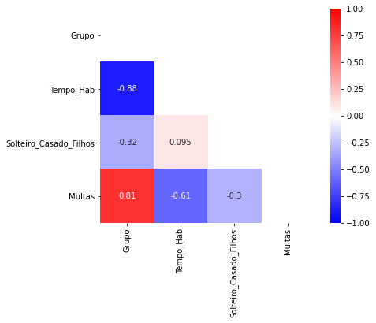

```python
correlacao = df[[Ystr] + Xstr].corr()
mask = np.zeros_like(correlacao)
mask[np.triu_indices_from(mask)] = True
f, ax = plt.subplots(figsize=(7, 5))
ax = sns.heatmap(correlacao, mask=mask, annot=True, cmap="bwr", square=True, vmin=-1.0, vmax=1.0)
```

### Cálculo dos Coeficientes de Regressão Linear Múltipla

```python
# Modelo de Regressão Linear Múltipla
formula = ' ~ '.join([Ystr, ' + '.join(Xstr)])
#formula
modelo_ajustado = smf.ols(formula=formula, data=df)
modelo_treinado = modelo_ajustado.fit()
modelo_treinado.summary()
```

OLS Regression Results

| Dep. Variable: | Grupo | R-squared: | 0.923 |
| --- | --- | --- | --- |
| Model: | OLS | Adj. R-squared: | 0.908 |
| Method: | Least Squares | F-statistic: | 63.82 |
| Date: | Sun, 31 May 2020 | Prob (F-statistic): | 4.03e-09 |
| Time: | 23:40:12 | Log-Likelihood: | 1.5915 |
| No. Observations: | 20 | AIC: | 4.817 |
| Df Residuals: | 16 | BIC: | 8.800 |
| Df Model: | 3 |  |  |
| Covariance Type: | nonrobust |  |  |

|  | coef | std err | t | P>\|t\| | [0.025 | 0.975] |
| --- | --- | --- | --- | --- | --- | --- |
| Intercept | 2.9359 | 0.292 | 10.059 | 0.000 | 2.317 | 3.555 |
| Tempo_Hab | -0.0756 | 0.010 | -7.303 | 0.000 | -0.098 | -0.054 |
| Solteiro_Casado_Filhos | -0.1522 | 0.076 | -2.001 | 0.063 | -0.314 | 0.009 |
| Multas | 0.0787 | 0.019 | 4.148 | 0.001 | 0.038 | 0.119 |

| Omnibus: | 0.146 | Durbin-Watson: | 1.089 |
| --- | --- | --- | --- |
| Prob(Omnibus): | 0.930 | Jarque-Bera (JB): | 0.259 |
| Skew: | 0.171 | Prob(JB): | 0.879 |
| Kurtosis: | 2.559 | Cond. No. | 82.1 |

Warnings:  
[1] Standard Errors assume that the covariance matrix of the errors is correctly specified.

### Análise da Regressão Linear Múltipla

- **Função Discriminante**:
  - $Z = 2,9359 -0,0756X_{Tempo\_Hab} -0,1522X_{Solteiro\_Casado\_Filhos} + 0,0787X_{Multas}$
- $R^2 = 0,923$ e $R_{Ajus}^2 = 0,908$ são maior que $70\%$ o que significa que o modelo determina fortemente a variável dependente.
- $P(F_{stat} <0,05)$ também reforça que o modelo é robusto
- $Tempo\_Hab$ e $Multas$ possuem significância estatística, pois $P_{Value} < 0,05$. Já $Solteiro\_Casado\_Filhos$ ficou a cima do $5\%$ o que sugere que ele possa ser removido do modelo, pois tem pouca significância estatística (é preciso fazer outro teste).

### Cálculo da Variável que mais Discrimina a Classificação dos Grupos

- Vamos fazer o método *stepwise forward* (incluindo variáveis) e *stepwise backward* (removendo variáveis).

```python
# FONTE: https://github.com/AakkashVijayakumar/stepwise-regression/blob/master/stepwise_regression/step_reg.py
def forward_regression(X, y,
                       threshold_in,
                       verbose=False):
    initial_list = []
    included = list(initial_list)
    while True:
        changed=False
        excluded = list(set(X.columns)-set(included))
        new_pval = pd.Series(index=excluded)
        for new_column in excluded:
            model = sm.OLS(y, sm.add_constant(pd.DataFrame(X[included+[new_column]]))).fit()
            new_pval[new_column] = model.pvalues[new_column]
        best_pval = new_pval.min()
        if best_pval < threshold_in:
            best_feature = new_pval.idxmin()
            included.append(best_feature)
            changed=True
            if verbose:
                print('-'*80)
                print('ADICIONA [{:30}] COM p-value {:.6}'.format(best_feature, best_pval))

        if not changed:
            break

    return included

def backward_regression(X, y,
                           threshold_out,
                           verbose=False):
    included=list(X.columns)
    while True:
        changed=False
        model = sm.OLS(y, sm.add_constant(pd.DataFrame(X[included]))).fit()
        # use all coefs except intercept
        pvalues = model.pvalues.iloc[1:]
        worst_pval = pvalues.max() # null if pvalues is empty
        if worst_pval > threshold_out:
            changed=True
            worst_feature = pvalues.idxmax()
            included.remove(worst_feature)
            if verbose:
                print('-'*80)
                print('REMOVE [{:30}] COM p-value {:.6}'.format(worst_feature, worst_pval))
        if not changed:
            break
    return included

# Dados Observados
X_train= df[Xstr]
Y_train = df[Ystr]

print('-'*80)
print('* STEPWISE-FORWARD')
print(forward_regression(X=X_train, y=Y_train, threshold_in=0.05, verbose=True))

print('-'*80)
print('* STEPWISE-BACKWARD')
print(backward_regression(X=X_train, y=Y_train, threshold_out=0.05, verbose=True))
```

```
--------------------------------------------------------------------------------
* STEPWISE-FORWARD
--------------------------------------------------------------------------------
ADICIONA [Tempo_Hab                     ] COM p-value 2.18738e-07
--------------------------------------------------------------------------------
ADICIONA [Multas                        ] COM p-value 0.000251423
['Tempo_Hab', 'Multas']
--------------------------------------------------------------------------------
* STEPWISE-BACKWARD
--------------------------------------------------------------------------------
REMOVE [Solteiro_Casado_Filhos        ] COM p-value 0.0626311
['Tempo_Hab', 'Multas']
```

### Análise da Variável que mais Discrimina a Classificação dos Grupos

Os resultados do método *stepwise* indicam que a variável $Tempo\_Hab$ é a mais significativa estatísticamente. A variável $Multas$ ficaria em segundo lugar e $Solteiro\_Casado\_Filhos$ pode ser removida do modelo, pois não possui significância estatística ($p_{value} = 0,0626311 > 0,05$).

### Calcular a Probabilidade de Cada Um dos Novos Clientes Pertencer ao Grupo Correspondente

- As colunas Pg1, Pg2 e Pg3 representam as probabilidades para cada grupo de cada uma das novas observações.

```python
# Testes
X_test = df_new_obs[Xstr]

#  Usa Mahalanobis Distance
from sklearn.discriminant_analysis import LinearDiscriminantAnalysis
clf = LinearDiscriminantAnalysis()
clf.fit(X_train, Y_train.values.ravel())
df_new_obs['Grupo-Predito-LDA'] = clf.predict(X_test)
# Estimate probability
proba = clf.predict_proba(X_test).round(2)

cols = ['Pg1', 'Pg2', 'Pg3']
for c in cols:
  df_new_obs[c] = 0.0
for i in range(len(df_new_obs.index)):
  df_new_obs.loc[i, cols] = proba[i]

df_new_obs
```

|  | Tempo_Hab | Solteiro_Casado_Filhos | Multas | mahala1 | mahala2 | mahala3 | Grupo-Predito | Grupo-Predito-LDA | Pg1 | Pg2 | Pg3 |
| --- | --- | --- | --- | --- | --- | --- | --- | --- | --- | --- | --- |
| 0 | 8 | 1 | 3 | 5.369668 | 1.994247 | 2.044610 | 2 | 2 | 0.00 | 0.87 | 0.13 |
| 1 | 2 | 1 | 6 | 8.382770 | 3.856047 | 1.884423 | 3 | 3 | 0.00 | 0.00 | 1.00 |
| 2 | 8 | 2 | 2 | 4.977031 | 2.071910 | 2.121387 | 2 | 2 | 0.00 | 1.00 | 0.00 |
| 3 | 20 | 2 | 4 | 2.402256 | 2.798912 | 3.903311 | 1 | 1 | 0.96 | 0.04 | 0.00 |
| 4 | 7 | 3 | 8 | 8.148364 | 3.536257 | 1.746979 | 3 | 3 | 0.00 | 0.14 | 0.86 |
| 5 | 15 | 3 | 1 | 2.684834 | 2.850259 | 3.646624 | 1 | 1 | 0.84 | 0.16 | 0.00 |
| 6 | 6 | 2 | 10 | 9.862598 | 4.796457 | 0.471789 | 3 | 3 | 0.00 | 0.00 | 1.00 |
| 7 | 3 | 3 | 5 | 7.497222 | 3.340843 | 2.347557 | 3 | 3 | 0.00 | 0.12 | 0.88 |

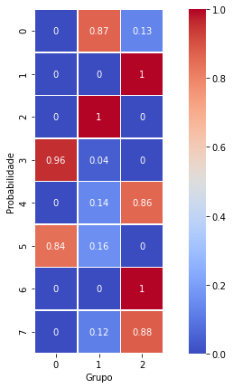

```python
f, ax = plt.subplots(figsize=(10, 7))
ax = sns.heatmap(proba, annot=True, cmap="coolwarm", linewidth=0.5, square=True, vmin=0.0, vmax=1.0)
ax.set_xlabel('Grupo')
ax.set_ylabel('Probabilidade')
```

### Regra de Negócio para Novos Clientes

- Calcular dos Escores Discriminantes
- Calcular os Centróides por Grupo
- Calcular de Ponto de Corte

```python
# Previsão dos Escores Discriminantes
previsao = modelo_treinado.predict(df[Xstr])
df['Escore_Discrim'] = previsao.values
df
```

|  | Observacao | Grupo | Tempo_Hab | Solteiro_Casado_Filhos | Multas | mahala1 | mahala2 | mahala3 | Grupo-Predito | Acertou | D12 | D13 | D23 | Escore_Discrim |
| --- | --- | --- | --- | --- | --- | --- | --- | --- | --- | --- | --- | --- | --- | --- |
| 0 | 1 | 1 | 20 | 3 | 1 | 1.258306 | 3.844643 | 4.603846 | 1 | True | 2.586337 | 3.345540 | 0.759203 | 1.045152 |
| 1 | 2 | 1 | 21 | 3 | 0 | 1.842779 | 4.565843 | 4.959718 | 1 | True | 2.723064 | 3.116940 | 0.393876 | 0.890810 |
| 2 | 3 | 1 | 25 | 3 | 2 | 1.376893 | 4.941296 | 5.619511 | 1 | True | 3.564403 | 4.242618 | 0.678215 | 0.745680 |
| 3 | 4 | 1 | 25 | 2 | 3 | 1.719981 | 4.593541 | 5.268686 | 1 | True | 2.873560 | 3.548705 | 0.675145 | 0.976631 |
| 4 | 5 | 1 | 18 | 2 | 2 | 1.506928 | 2.643755 | 3.690107 | 1 | True | 1.136826 | 2.183179 | 1.046352 | 1.427374 |
| 5 | 6 | 1 | 23 | 1 | 2 | 1.701715 | 4.322739 | 4.948794 | 1 | True | 2.621024 | 3.247079 | 0.626056 | 1.201441 |
| 6 | 7 | 2 | 9 | 3 | 6 | 6.276610 | 2.090238 | 2.034983 | 3 | False | 4.186372 | 4.241627 | 0.055255 | 2.270672 |
| 7 | 8 | 2 | 12 | 2 | 4 | 4.215547 | 0.116987 | 2.093015 | 2 | True | 4.098560 | 2.122531 | 1.976028 | 2.038599 |
| 8 | 9 | 2 | 15 | 1 | 3 | 3.233935 | 1.840417 | 3.000625 | 2 | True | 1.393518 | 0.233310 | 1.160208 | 1.885231 |
| 9 | 10 | 2 | 14 | 2 | 2 | 2.875906 | 1.754801 | 2.861700 | 2 | True | 1.121104 | 0.014205 | 1.106899 | 1.729916 |
| 10 | 11 | 2 | 15 | 1 | 5 | 4.382731 | 1.752525 | 2.706895 | 2 | True | 2.630206 | 1.675836 | 0.954370 | 2.042643 |
| 11 | 12 | 2 | 10 | 3 | 5 | 5.392897 | 1.520828 | 2.267157 | 2 | True | 3.872069 | 3.125740 | 0.746329 | 2.116331 |
| 12 | 13 | 2 | 8 | 2 | 4 | 5.456266 | 1.329096 | 1.585871 | 2 | True | 4.127170 | 3.870394 | 0.256776 | 2.341141 |
| 13 | 14 | 3 | 7 | 2 | 13 | 12.194603 | 6.792399 | 1.062610 | 3 | True | 5.402203 | 11.131992 | 5.729789 | 3.125129 |
| 14 | 15 | 3 | 11 | 1 | 15 | 13.581544 | 8.168815 | 2.136116 | 3 | True | 5.412729 | 11.445428 | 6.032699 | 3.132243 |
| 15 | 16 | 3 | 10 | 2 | 9 | 8.281505 | 3.666674 | 0.943399 | 3 | True | 4.614832 | 7.338107 | 2.723275 | 2.583399 |
| 16 | 17 | 3 | 7 | 2 | 6 | 6.774646 | 2.165484 | 1.025639 | 3 | True | 4.609162 | 5.749008 | 1.139846 | 2.574188 |
| 17 | 18 | 3 | 9 | 1 | 10 | 9.428459 | 4.628361 | 1.121964 | 3 | True | 4.800097 | 8.306494 | 3.506397 | 2.889985 |
| 18 | 19 | 3 | 1 | 3 | 8 | 9.664152 | 4.860937 | 2.365609 | 3 | True | 4.803215 | 7.298543 | 2.495328 | 3.033168 |
| 19 | 20 | 3 | 3 | 1 | 5 | 7.629439 | 3.340843 | 1.873773 | 3 | True | 4.288596 | 5.755665 | 1.467070 | 2.950269 |

```python
# Cálculo dos Centróides por Grupo
df_centroide = pd.DataFrame()

for i in grupos:
    df_centroide.loc[i, 'Centroide'] = df.loc[df[Ystr] == i]['Escore_Discrim'].mean()

df_centroide
```

|  | Centroide |
| --- | --- |
| 1 | 1.047848 |
| 2 | 2.060647 |
| 3 | 2.898340 |

```python
# Cálculo de Ponto de Corte
pc1 = (df_centroide.loc[1, 'Centroide'] + df_centroide.loc[2, 'Centroide'])/2
pc2 = (df_centroide.loc[2, 'Centroide'] + df_centroide.loc[3, 'Centroide'])/2

print('-'*110)
print(f"PONTO DE CORTE ENTRE GRUPO 1 E 2: {num_format_flo(pc1)} | REGRA DE NEGOCIO 80%: {num_format_flo(pc1*0.8)}")
print('-'*110)
print(f"PONTO DE CORTE ENTRE GRUPO 2 E 3: {num_format_flo(pc2)} | REGRA DE NEGOCIO 80%: {num_format_flo(pc2*0.8)}")
print('-'*110)

df['ED_Grp_Prev'] = -1
df.loc[df['Escore_Discrim'] < pc1, ['ED_Grp_Prev']] = 1
df.loc[(df['Escore_Discrim'] >= pc1) & (df['Escore_Discrim'] < pc2), ['ED_Grp_Prev']] = 2
df.loc[df['Escore_Discrim'] >= pc2, ['ED_Grp_Prev']] = 3
df
```

```
--------------------------------------------------------------------------------------------------------------
PONTO DE CORTE ENTRE GRUPO 1 E 2:           1.5542475937 | REGRA DE NEGOCIO 80%:           1.2433980749
--------------------------------------------------------------------------------------------------------------
PONTO DE CORTE ENTRE GRUPO 2 E 3:           2.4794937649 | REGRA DE NEGOCIO 80%:           1.9835950119
--------------------------------------------------------------------------------------------------------------
```

|  | Observacao | Grupo | Tempo_Hab | Solteiro_Casado_Filhos | Multas | mahala1 | mahala2 | mahala3 | Grupo-Predito | Acertou | D12 | D13 | D23 | Escore_Discrim | ED_Grp_Prev |
| --- | --- | --- | --- | --- | --- | --- | --- | --- | --- | --- | --- | --- | --- | --- | --- |
| 0 | 1 | 1 | 20 | 3 | 1 | 1.258306 | 3.844643 | 4.603846 | 1 | True | 2.586337 | 3.345540 | 0.759203 | 1.045152 | 1 |
| 1 | 2 | 1 | 21 | 3 | 0 | 1.842779 | 4.565843 | 4.959718 | 1 | True | 2.723064 | 3.116940 | 0.393876 | 0.890810 | 1 |
| 2 | 3 | 1 | 25 | 3 | 2 | 1.376893 | 4.941296 | 5.619511 | 1 | True | 3.564403 | 4.242618 | 0.678215 | 0.745680 | 1 |
| 3 | 4 | 1 | 25 | 2 | 3 | 1.719981 | 4.593541 | 5.268686 | 1 | True | 2.873560 | 3.548705 | 0.675145 | 0.976631 | 1 |
| 4 | 5 | 1 | 18 | 2 | 2 | 1.506928 | 2.643755 | 3.690107 | 1 | True | 1.136826 | 2.183179 | 1.046352 | 1.427374 | 1 |
| 5 | 6 | 1 | 23 | 1 | 2 | 1.701715 | 4.322739 | 4.948794 | 1 | True | 2.621024 | 3.247079 | 0.626056 | 1.201441 | 1 |
| 6 | 7 | 2 | 9 | 3 | 6 | 6.276610 | 2.090238 | 2.034983 | 3 | False | 4.186372 | 4.241627 | 0.055255 | 2.270672 | 2 |
| 7 | 8 | 2 | 12 | 2 | 4 | 4.215547 | 0.116987 | 2.093015 | 2 | True | 4.098560 | 2.122531 | 1.976028 | 2.038599 | 2 |
| 8 | 9 | 2 | 15 | 1 | 3 | 3.233935 | 1.840417 | 3.000625 | 2 | True | 1.393518 | 0.233310 | 1.160208 | 1.885231 | 2 |
| 9 | 10 | 2 | 14 | 2 | 2 | 2.875906 | 1.754801 | 2.861700 | 2 | True | 1.121104 | 0.014205 | 1.106899 | 1.729916 | 2 |
| 10 | 11 | 2 | 15 | 1 | 5 | 4.382731 | 1.752525 | 2.706895 | 2 | True | 2.630206 | 1.675836 | 0.954370 | 2.042643 | 2 |
| 11 | 12 | 2 | 10 | 3 | 5 | 5.392897 | 1.520828 | 2.267157 | 2 | True | 3.872069 | 3.125740 | 0.746329 | 2.116331 | 2 |
| 12 | 13 | 2 | 8 | 2 | 4 | 5.456266 | 1.329096 | 1.585871 | 2 | True | 4.127170 | 3.870394 | 0.256776 | 2.341141 | 2 |
| 13 | 14 | 3 | 7 | 2 | 13 | 12.194603 | 6.792399 | 1.062610 | 3 | True | 5.402203 | 11.131992 | 5.729789 | 3.125129 | 3 |
| 14 | 15 | 3 | 11 | 1 | 15 | 13.581544 | 8.168815 | 2.136116 | 3 | True | 5.412729 | 11.445428 | 6.032699 | 3.132243 | 3 |
| 15 | 16 | 3 | 10 | 2 | 9 | 8.281505 | 3.666674 | 0.943399 | 3 | True | 4.614832 | 7.338107 | 2.723275 | 2.583399 | 3 |
| 16 | 17 | 3 | 7 | 2 | 6 | 6.774646 | 2.165484 | 1.025639 | 3 | True | 4.609162 | 5.749008 | 1.139846 | 2.574188 | 3 |
| 17 | 18 | 3 | 9 | 1 | 10 | 9.428459 | 4.628361 | 1.121964 | 3 | True | 4.800097 | 8.306494 | 3.506397 | 2.889985 | 3 |
| 18 | 19 | 3 | 1 | 3 | 8 | 9.664152 | 4.860937 | 2.365609 | 3 | True | 4.803215 | 7.298543 | 2.495328 | 3.033168 | 3 |
| 19 | 20 | 3 | 3 | 1 | 5 | 7.629439 | 3.340843 | 1.873773 | 3 | True | 4.288596 | 5.755665 | 1.467070 | 2.950269 | 3 |

### A Regra de Negócio:

Uma sugestão de regra negócio seria usa $80\%$ dos pontos de corte para as fronteiras entre os grupos $(1,2)$ e $(2,3)$. Assim, um novo cliente que obtivesse um valor e escore discriminante abaixo de $1,24$ seria classificado no grupo $1$, entre $1,24$ e $1,98$ seria classificado no grupo $2$ e acima de $1,98$ no grupo $3$. Assim, uma margem de segurança seria criada protegendo seguradora e aumentando o limitar para que um novo cliente seja enquadrado nos grupos de menores riscos.